# Chapter 18 Anova Diagnostics and Remedial Measures

Bryan Goodrich

2015-08-08

# Chapter 18 – ANOVA Diagnostics and Remedial Measures

## Load the data sets

```r
library(SuppDists)  # qmaxFratio
library(HH)         # hov
library(MASS)       # boxcox

data("CH17TA02", package = "ALSM")
data("CH18TA02", package = "ALSM")
data("CH18TA05", package = "ALSM")
data("CH18TA07", package = "ALSM")
```

## Input Rust Inhibitor Data

```r
.data <- CH17TA02
names(.data) <- c("y", "x1", "x2")
fit <- lm(y ~ factor(x1)-1, .data)
```

## TABLE 18.1 (p 777)

#### Residuals–Rust Inhibitor Example

```r
xtabs(resid(fit) ~ x2 + x1, .data)
```

```
##     x1
## x2       1     2     3     4
##   1   0.76  0.36  0.45 -4.27
##   2  -4.14 -2.34  1.35  4.73
##   3   3.56  3.26  0.55  0.23
##   4   0.66  1.16 -1.55  0.03
##   5   1.06 -1.74  2.05 -1.17
##   6   4.56  2.96  0.15 -0.17
##   7   0.46 -3.34  2.65  2.73
##   8  -4.24 -1.34 -2.75 -1.77
##   9   0.46  1.36 -4.15  0.43
##   10 -3.14 -0.34  1.25 -0.77
```

## FIGURE 18.1 (p 777)

#### Diagnostic Residual Plot–Rust Inhibitor Example

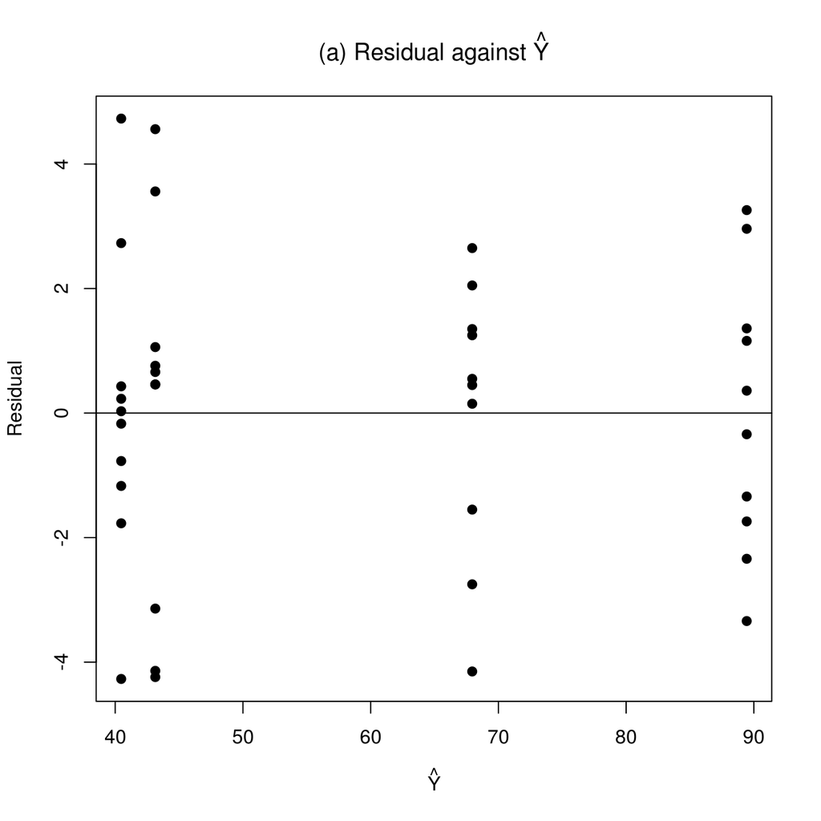

```r
plot(resid(fit) ~ fitted(fit), ylab = "Residual", xlab = expression(hat(Y)), pch = 19)
abline(0,0)
title(expression(paste("(a) Residual against ", hat(Y))))
```

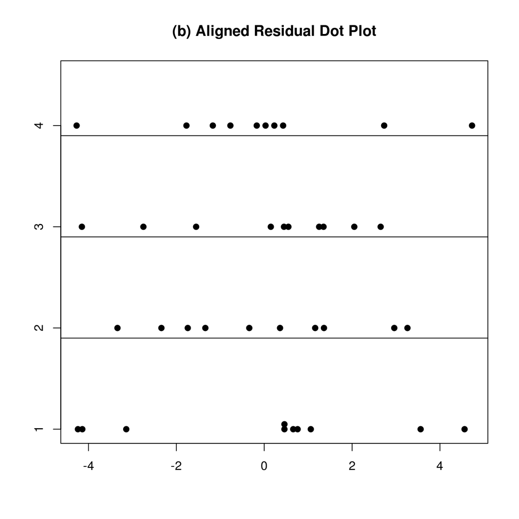

```r
stripchart(split(resid(fit), .data$x1), method = "stack",  pch = 19)
abline(h = seq(2, 4)-0.1)
title("(b) Aligned Residual Dot Plot")
```

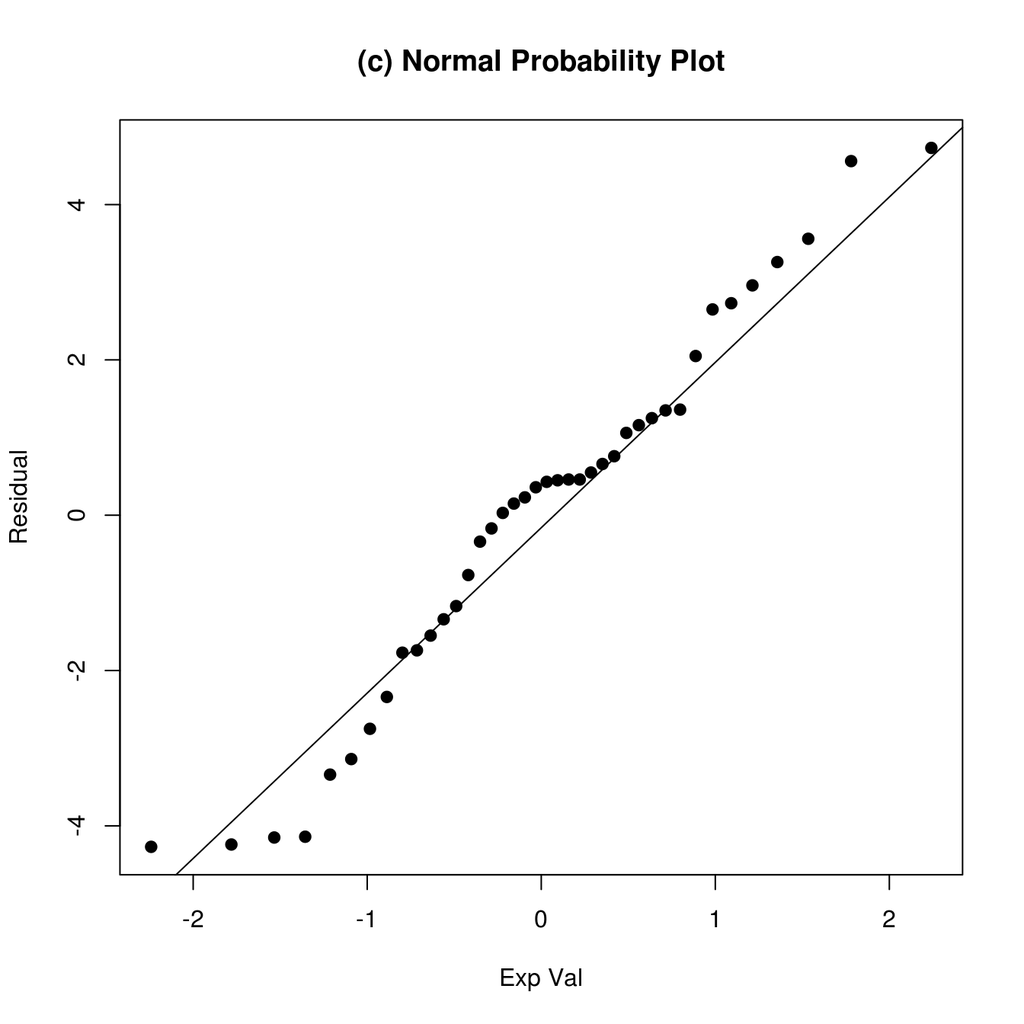

```r
qqnorm(resid(fit), xlab = "Exp Val", ylab = "Residual", pch = 19, main = "")
qqline(resid(fit))
title("(c) Normal Probability Plot")
```

## FIGURE 18.2 - 18.5

Omitted; No data

## Input ABT Electronics Data

```r
.data <- CH18TA02
names(.data) <- c("y", "x1", "x2")
```

## TABLE 18.2 (p 783)

#### Solder Joint Pull Strength–ABT Electronics Example

R has a function for the H distribution used in this example. It comes from `maxFratio` (*SuppDists*). The df and r (k) are reversed in its arguments from those used in the book. Note that (18.10) just is the variance (var) function applied to each factor level, as used below.

```r
tab <- xtabs(y ~ x2 + x1, .data)
round(addmargins(tab, 1, FUN = list(list(mean, median, s = var))), 3)
```

```
##         x1
## x2            1      2      3      4      5
##   1      14.870 18.430 16.950  8.590 11.550
##   2      16.810 18.760 12.280 10.900 13.360
##   3      15.830 20.120 12.000  8.600 13.640
##   4      15.470 19.110 13.180 10.130 12.160
##   5      13.600 19.810 14.990 10.280 11.620
##   6      14.760 18.430 15.760  9.980 12.390
##   7      17.400 17.160 19.350  9.410 12.050
##   8      14.620 16.400 15.520 10.040 11.950
##   mean   15.420 18.527 15.004  9.741 12.340
##   median 15.170 18.595 15.255 10.010 12.105
##   s       1.531  1.570  6.183  0.667  0.592
```

```r
vars <- with(.data, tapply(y, x1, var))  # (18.10)
cat("H* = ", max(vars) / min(vars))   # (18.8)
```

```
## H* =  10.44
```

```r
qmaxFratio(0.95, 7, 5)                # (18.9)
```

```
## [1] 9.697
```

## FIGURE 18.6 (p 784)

#### Dot Plots of Pull Strengths–ABT Electronics Example

We round the `y` values so they actually stack at integer points. Otherwise, they’re recognized as different numeric values and do not stack as desired.

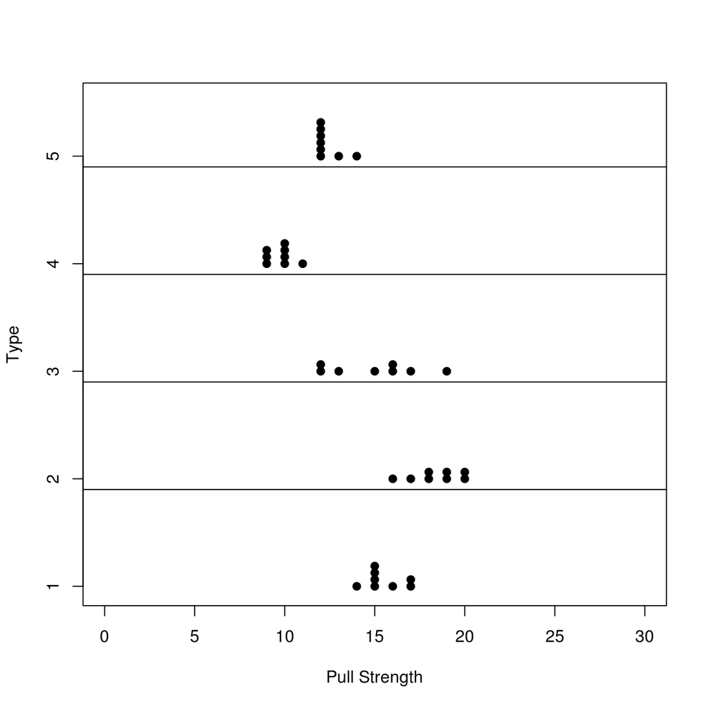

```r
stripchart(round(y) ~ x1, .data, pch = 19, method = "stack", xlim = c(0, 30), xlab = "Pull Strength", ylab = "Type")
abline(h = seq(2,5) - 0.1)
```

## TABLE 18.3 (p 785)

#### Absolute Deviations of Responses from Treatment Medians–ABT Electronics Example

R does contain a function for the Brown-Forsythe test called `hov` (*HH*). Since this test is not nearly as simple as the Hartley test, which is one of its prime advantages, making use of `hov` is a time saver. The `BF` computations serve no pedagogical value at this time, so they will be omitted.

```r
hov(y ~ factor(x1), .data)
```

```
##
##  hov: Brown-Forsyth
##
## data:  y
## F = 2.9, df:factor(x1) = 4, df:Residuals = 35, p-value = 0.03
## alternative hypothesis: variances are not identical
```

```r
data.frame(with(.data, tapply(y, x1, function(x) list(abs(x - median(x))))))
```

```
##     X1    X2    X3   X4    X5
## 1 0.30 0.165 1.695 1.42 0.555
## 2 1.64 0.165 2.975 0.89 1.255
## 3 0.66 1.525 3.255 1.41 1.535
## 4 0.30 0.515 2.075 0.12 0.055
## 5 1.57 1.215 0.265 0.27 0.485
## 6 0.41 0.165 0.505 0.03 0.285
## 7 2.23 1.435 4.095 0.60 0.055
## 8 0.55 2.195 0.265 0.03 0.155
```

## FIGURE 18.7 and TABLE 18.4 (p 788)

#### Weighted Regression Output for Full and reduced Models–ABT Electronics Example

#### Data for Weighted Least Squares Regression–ABT Electronics Example

```r
w = 1 / vars          # Factor level variances (18.10) defined earlier
w = rep(w, each = 8)  # (18.14) -- Repeat each weight by # of x2 factor levels
fit <- lm(y ~ x1 -1, transform(.data, x1 = factor(x1)), weights = w)  # (18.17)

data.frame(
  'i' = .data$x1,
  'j' = .data$x2,
  'Y' = .data$y,
  model.matrix(fit),
  'Weights' = w,
  'Reduced.Model' = 1)
```

```
##    i j     Y x11 x12 x13 x14 x15 Weights Reduced.Model
## 1  1 1 14.87   1   0   0   0   0  0.6534             1
## 2  1 2 16.81   1   0   0   0   0  0.6534             1
## 3  1 3 15.83   1   0   0   0   0  0.6534             1
## 4  1 4 15.47   1   0   0   0   0  0.6534             1
## 5  1 5 13.60   1   0   0   0   0  0.6534             1
## 6  1 6 14.76   1   0   0   0   0  0.6534             1
## 7  1 7 17.40   1   0   0   0   0  0.6534             1
## 8  1 8 14.62   1   0   0   0   0  0.6534             1
## 9  2 1 18.43   0   1   0   0   0  0.6370             1
## 10 2 2 18.76   0   1   0   0   0  0.6370             1
## 11 2 3 20.12   0   1   0   0   0  0.6370             1
## 12 2 4 19.11   0   1   0   0   0  0.6370             1
## 13 2 5 19.81   0   1   0   0   0  0.6370             1
## 14 2 6 18.43   0   1   0   0   0  0.6370             1
```

[output cut: 26 more lines]

```r
summary(fit)
```

```
##
## Call:
## lm(formula = y ~ x1 - 1, data = transform(.data, x1 = factor(x1)),
##     weights = w)
##
## Weighted Residuals:
##     Min      1Q  Median      3Q     Max
## -1.6980 -0.6683  0.0174  0.5220  1.7478
##
## Coefficients:
##     Estimate Std. Error t value Pr(>|t|)
## x11   15.420      0.437    35.2   <2e-16 ***
## x12   18.528      0.443    41.8   <2e-16 ***
## x13   15.004      0.879    17.1   <2e-16 ***
## x14    9.741      0.289    33.7   <2e-16 ***
## x15   12.340      0.272    45.4   <2e-16 ***
## ---
## Signif. codes:  0 '***' 0.001 '**' 0.01 '*' 0.05 '.' 0.1 ' ' 1
##
## Residual standard error: 1 on 35 degrees of freedom
## Multiple R-squared:  0.995,  Adjusted R-squared:  0.994
## F-statistic: 1.3e+03 on 5 and 35 DF,  p-value: <2e-16
```

```r
anova(fit)
```

```
## Analysis of Variance Table
##
## Response: y
##           Df Sum Sq Mean Sq F value Pr(>F)
## x1         5   6479    1296    1296 <2e-16 ***
## Residuals 35     35       1
## ---
## Signif. codes:  0 '***' 0.001 '**' 0.01 '*' 0.05 '.' 0.1 ' ' 1
```

```r
summary(lm(y ~ 1, .data, weights = w))  # Reduced Model (18.19)
```

```
##
## Call:
## lm(formula = y ~ 1, data = .data, weights = w)
##
## Weighted Residuals:
##    Min     1Q Median     3Q    Max
## -5.249 -1.311  0.922  2.656  5.781
##
## Coefficients:
##             Estimate Std. Error t value Pr(>|t|)
## (Intercept)   12.876      0.498    25.9   <2e-16 ***
## ---
## Signif. codes:  0 '***' 0.001 '**' 0.01 '*' 0.05 '.' 0.1 ' ' 1
##
## Residual standard error: 3.03 on 39 degrees of freedom
```

```r
anova(lm(y ~ 1, .data, weights = w))
```

```
## Analysis of Variance Table
##
## Response: y
##           Df Sum Sq Mean Sq F value Pr(>F)
## Residuals 39    359    9.21
```

```r
anova(lm(y ~ 1, .data, weights = w), fit)  # Confirm that x1 is significant to keep
```

```
## Analysis of Variance Table
##
## Model 1: y ~ 1
## Model 2: y ~ x1 - 1
##   Res.Df RSS Df Sum of Sq  F Pr(>F)
## 1     39 359
## 2     35  35  4       324 81 <2e-16 ***
## ---
## Signif. codes:  0 '***' 0.001 '**' 0.01 '*' 0.05 '.' 0.1 ' ' 1
```

## Input the Servo Data

```r
.data <- CH18TA05
names(.data) <- c("y", "x1", "x2")
```

## TABLE 18.5 (p 791)

#### Time between Computer Failures at Three Locations (in hours)–Servo-Data Example

```r
addmargins(xtabs(y ~ x2 + x1, .data), 1, list(list(mean, var)))
```

```
##       x1
## x2            1        2        3
##   1        4.41     8.24   106.19
##   2      100.65    81.16    33.83
##   3       14.45     7.35    78.88
##   4       47.13    12.29   342.81
##   5       85.21     1.61    44.33
##   mean    50.37    22.13   121.21
##   var   1788.74  1103.45 16167.45
```

```r
addmargins(xtabs(rank(y) ~ x2 + x1, .data), 1, list(list(mean, var)))
```

```
##       x1
## x2        1    2    3
##   1     2.0  4.0 14.0
##   2    13.0 11.0  7.0
##   3     6.0  3.0 10.0
##   4     9.0  5.0 15.0
##   5    12.0  1.0  8.0
##   mean  8.4  4.8 10.8
##   var  20.3 14.2 12.7
```

```r
cbind(
  '(1)' = with(.data, tapply(y, x1, function(x) var(x) / mean(x))),
  '(2)' = with(.data, tapply(y, x1, function(x) sd(x)  / mean(x))),
  '(3)' = with(.data, tapply(y, x1, function(x) sd(x)  / mean(x)^2)))
```

```
##      (1)    (2)      (3)
## 1  35.51 0.8397 0.016670
## 2  49.86 1.5011 0.067829
## 3 133.39 1.0490 0.008655
```

## TABLE 18.6 and FIGURE 18.8 (p 792)

#### Normal Probability Plots for Original and Transformed Data–Servo-data Example

See `Chapter 3` for details on manual calculations. Instead, `boxcox` (*MASS*) will be used.

We do not show the Bonferroni corrected confidence intervals. Instead, we’re just going to see if there exists any pairwise differences. To this end `pairwise.t.test` with the `p.adj = 'bonf'` parameter set will suffice. It produces a pairwise matrix of p-values. In this case, “3-2” has a p-value of 5% indicating their is a statistically significant difference between the two means. We also provide a TukeyHSD result for comparison. Review the methods to check this appropriateness.

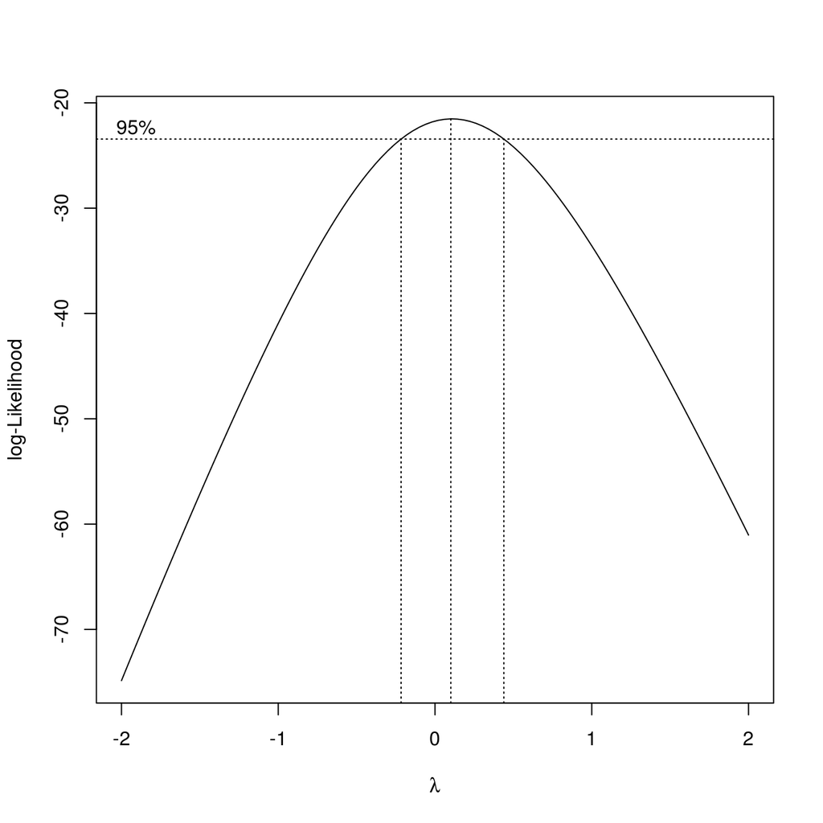

```r
fit <- lm(y ~ factor(x1) - 1, .data)
boxcox(fit)
```

```r
with(.data, tapply(log(y), x1, var))   # More stable variances (p 792)
```

```
##      1      2      3
## 1.7420 1.9736 0.8181
```

```r
with(.data, tapply(log(y), x1, mean))  # Transformed means (p 793)
```

```
##     1     2     3
## 3.413 2.297 4.437
```

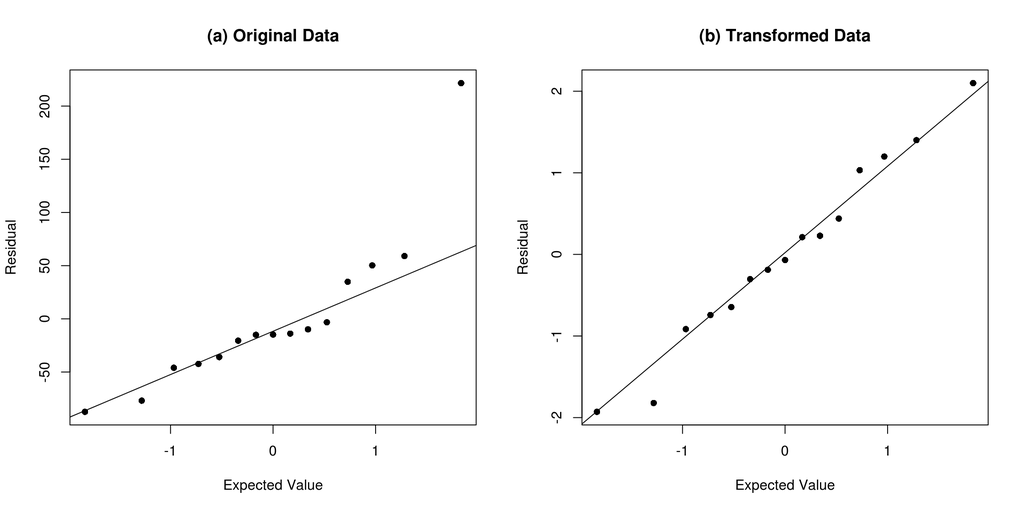

```r
par(mfrow = c(1, 2), pch = 16)
qqnorm(resid(fit), xlab = "Expected Value", ylab = "Residual", main = "")
qqline(resid(fit))
title("(a) Original Data")

fit <- update(fit, log(.) ~ .)
qqnorm(resid(fit), xlab = "Expected Value", ylab = "Residual", main = "")
qqline(resid(fit))
title("(b) Transformed Data")
```

```r
  ## Some statistics (p 793)
anova(lm(log(y) ~ 1, .data), fit)  # anova(reduced, full)
```

```
## Analysis of Variance Table
##
## Model 1: log(y) ~ 1
## Model 2: log(y) ~ factor(x1) - 1
##   Res.Df  RSS Df Sum of Sq    F Pr(>F)
## 1     14 29.6
## 2     12 18.1  2      11.4 3.79  0.053 .
## ---
## Signif. codes:  0 '***' 0.001 '**' 0.01 '*' 0.05 '.' 0.1 ' ' 1
```

```r
qf(0.90, 2, 12)                 # Compare with above F*
```

```
## [1] 2.807
```

```r
summary(fit)                    # Authors typo mean(location2) = 2.792
```

```
##
## Call:
## lm(formula = log(y) ~ factor(x1) - 1, data = .data)
##
## Residuals:
##     Min      1Q  Median      3Q     Max
## -1.9290 -0.6936 -0.0687  0.7362  2.0994
##
## Coefficients:
##             Estimate Std. Error t value  Pr(>|t|)
## factor(x1)1     3.41       0.55    6.21 0.0000453 ***
## factor(x1)2     2.30       0.55    4.18    0.0013 **
## factor(x1)3     4.44       0.55    8.07 0.0000034 ***
## ---
## Signif. codes:  0 '***' 0.001 '**' 0.01 '*' 0.05 '.' 0.1 ' ' 1
##
## Residual standard error: 1.23 on 12 degrees of freedom
## Multiple R-squared:  0.91,   Adjusted R-squared:  0.887
## F-statistic: 40.4 on 3 and 12 DF,  p-value: 0.00000151
```

```r
with(.data, pairwise.t.test(log(y), x1, p.adj = "bonf", conf.level = 0.9))
```

```
##
##  Pairwise comparisons using t tests with pooled SD
##
## data:  log(y) and x1
##
##   1    2
## 2 0.53 -
## 3 0.64 0.05
##
## P value adjustment method: bonferroni
```

```r
TukeyHSD(aov(log(y) ~ factor(x1), .data), conf.level = 0.90)
```

```
##   Tukey multiple comparisons of means
##     90% family-wise confidence level
##
## Fit: aov(formula = log(y) ~ factor(x1), data = .data)
##
## $`factor(x1)`
##       diff     lwr    upr  p adj
## 2-1 -1.116 -2.8772 0.6456 0.3549
## 3-1  1.024 -0.7376 2.7852 0.4131
## 3-2  2.140  0.3782 3.9011 0.0431
```

## EXAMPLE (p 795-8)

#### Nonparametric Rank F Test and Multiple Pairwise Testing Procedure–Servo-Data Example

We provide the F-value in the ANOVA output for this nonparametric ranked response model. Per the author’s comment (p 796), we also include the Kruskal-Wallis test using `kruskal.test` (*stats*). The results are very close in both cases. We manually calculate the multiple pairwise comparisons.

```r
fit <- lm(rank(y) ~ factor(x1), .data)
addmargins(xtabs(rank(y) ~ x2 + x1, .data), 1, list(list(mean, var)))  # Same results as earlier
```

```
##       x1
## x2        1    2    3
##   1     2.0  4.0 14.0
##   2    13.0 11.0  7.0
##   3     6.0  3.0 10.0
##   4     9.0  5.0 15.0
##   5    12.0  1.0  8.0
##   mean  8.4  4.8 10.8
##   var  20.3 14.2 12.7
```

```r
anova(fit)  # Compare F-value with value below
```

```
## Analysis of Variance Table
##
## Response: rank(y)
##            Df Sum Sq Mean Sq F value Pr(>F)
## factor(x1)  2   91.2    45.6     2.9  0.094 .
## Residuals  12  188.8    15.7
## ---
## Signif. codes:  0 '***' 0.001 '**' 0.01 '*' 0.05 '.' 0.1 ' ' 1
```

```r
cat("F* =", qf(0.90, 2, 12))
```

```
## F* = 2.807
```

```r
kruskal.test(y ~ x1, .data)  # Compare the chi-squared value with value below
```

```
##
##  Kruskal-Wallis rank sum test
##
## data:  y by x1
## Kruskal-Wallis chi-squared = 4.6, df = 2, p-value = 0.1
```

```r
cat("chi* =", qchisq(0.90, 2))
```

```
## chi* = 4.605
```

```r
# Multiple Pairwise Comparisons
B = qnorm(1 - 0.1 / 6) * sqrt((15 * (15 + 1)) / 12 * (1/5 + 1/5))
m = with(.data, tapply(rank(y), x1, mean))
round(rbind(
  "1-2" = c('diff' = m[[1]] - m[[2]], (m[1] - m[2]) + c('lwr' = -B, 'upr' =  B)),
  "3-2" = c('diff' = m[[3]] - m[[2]], (m[3] - m[2]) + c('lwr' = -B, 'upr' =  B)),
  "3-1" = c('diff' = m[[3]] - m[[1]], (m[3] - m[1]) + c('lwr' = -B, 'upr' =  B))), 1)
```

```
##     diff  lwr  upr
## 1-2  3.6 -2.4  9.6
## 3-2  6.0  0.0 12.0
## 3-1  2.4 -3.6  8.4
```

## Input Heart Transplant Data

```r
.data <- CH18TA07
names(.data) <-  c("y", "x")
.data <- transform(.data, x = factor(x, labels = c("Low", "Medium", "High")))
```

## TABLE 18.7 (p 798)

#### Survival Times of Patients Following Heart Transplant Surgery–Heart Transplant Example

Since the number of observations per treatment vary, we cannot present this in tabular form in R. Instead, we simply split them and show the separate treatment vectors of the response.

```r
with(.data, split(y, x))
```

```
## $Low
##  [1]   44  551  127    1  297   46   60   65   12 1350  730   47  994   26
##
## $Medium
##  [1]   15  280 1024  253   66   29  161  624   39   51   68  836   51
##
## $High
##  [1]   3 136  65  25  64 322  23  54  63  50  10  48
```

## FIGURE 18.9 (p 799)

#### Diagnostic Plots–Heart Transplant Example

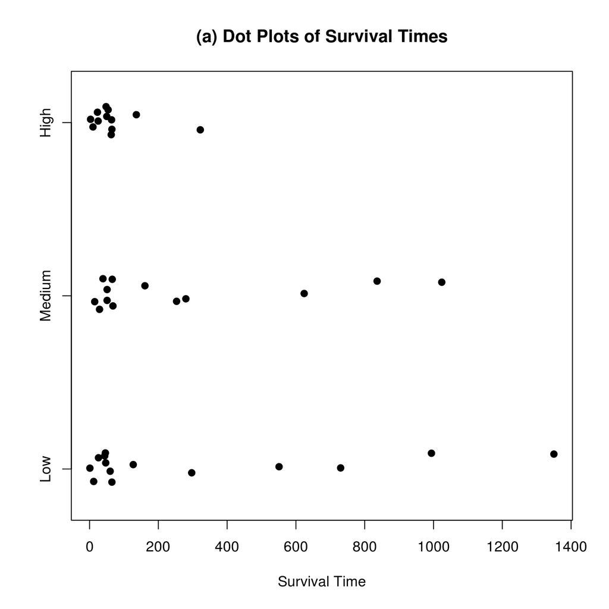

```r
fit <- lm(y ~ x - 1, .data)

stripchart(y ~ x, .data, method = "jitter", pch = 19, xlab = "Survival Time")
title("(a) Dot Plots of Survival Times")
```

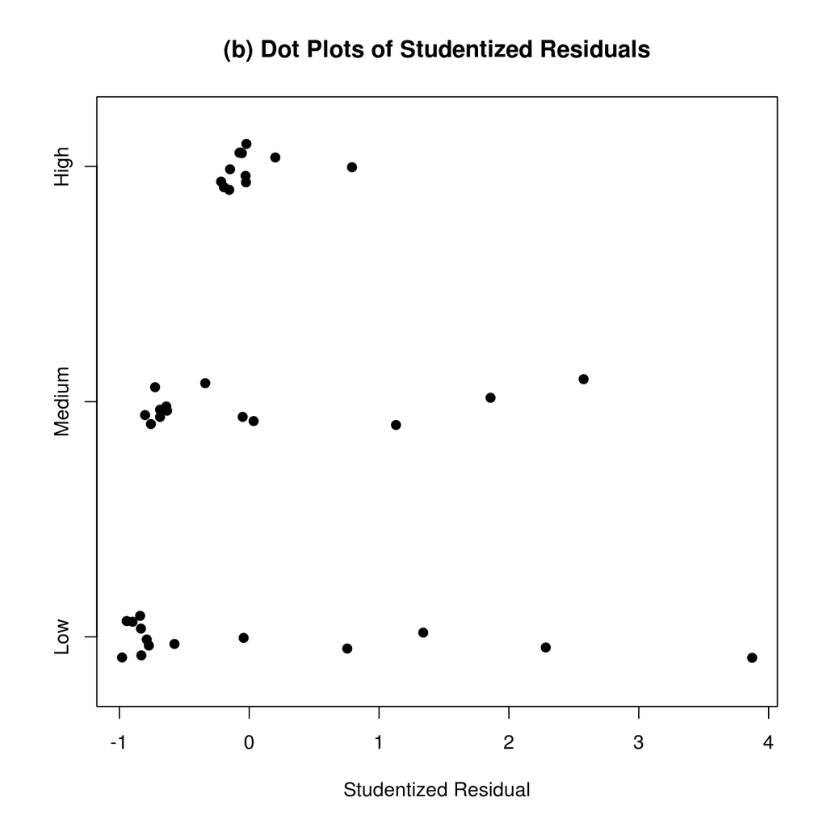

```r
stripchart(rstudent(fit) ~ x, .data, method = "jitter", pch = 19, xlab = "Studentized Residual")
title("(b) Dot Plots of Studentized Residuals")
```

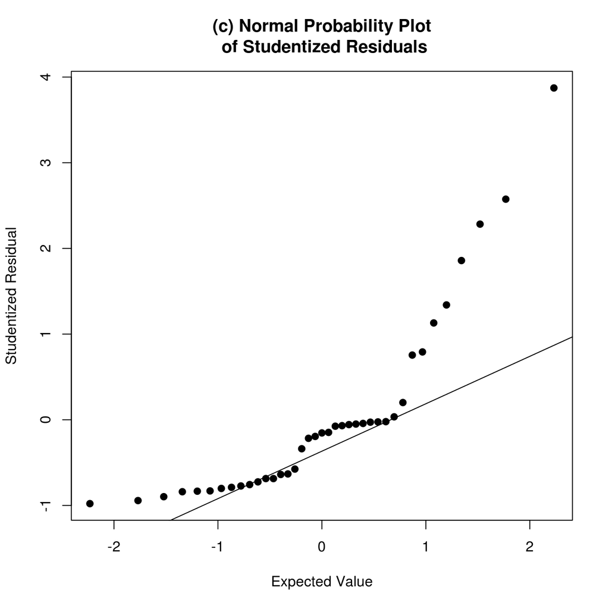

```r
qqnorm(rstudent(fit), pch = 19, xlab = "Expected Value", ylab = "Studentized Residual", main = "")
qqline(rstudent(fit))
title("(c) Normal Probability Plot\n of Studentized Residuals")
```

```r
hov(y ~ x, .data)  # (p 799) test for constancy of variance
```

```
##
##  hov: Brown-Forsyth
##
## data:  y
## F = 1.9, df:x = 2, df:Residuals = 36, p-value = 0.2
## alternative hypothesis: variances are not identical
```

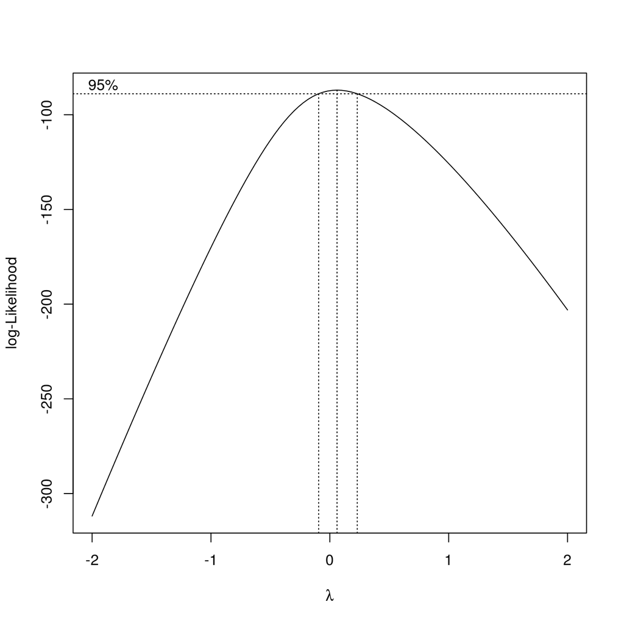

```r
boxcox(fit)
```

## FIGURE 18.10 (p 800)

#### Diagnostic Plots and ANOVA Table for Transformed Data–Heart Transplant Example

```r
fit <- lm(log(y) ~ x, .data)
summary(fit)
```

```
##
## Call:
## lm(formula = log(y) ~ x, data = .data)
##
## Residuals:
##    Min     1Q Median     3Q    Max
## -4.502 -0.791  0.147  1.013  2.706
##
## Coefficients:
##             Estimate Std. Error t value Pr(>|t|)
## (Intercept)    4.502      0.417   10.78    8e-13 ***
## xMedium        0.295      0.602    0.49     0.63
## xHigh         -0.778      0.614   -1.27     0.21
## ---
## Signif. codes:  0 '***' 0.001 '**' 0.01 '*' 0.05 '.' 0.1 ' ' 1
##
## Residual standard error: 1.56 on 36 degrees of freedom
## Multiple R-squared:  0.0797, Adjusted R-squared:  0.0286
## F-statistic: 1.56 on 2 and 36 DF,  p-value: 0.224
```

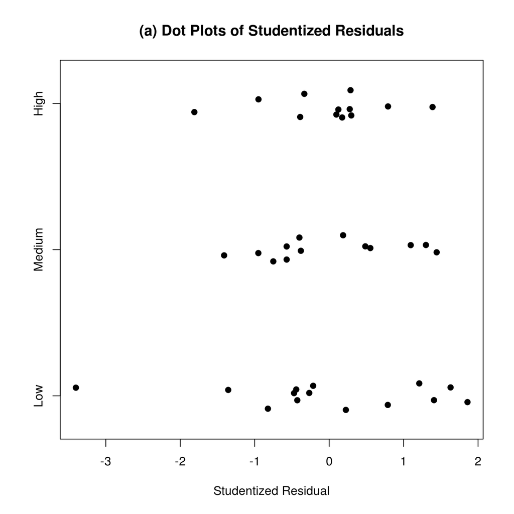

```r
stripchart(rstudent(fit) ~ x, .data, method = "jitter", pch = 19, xlab = "Studentized Residual")
title("(a) Dot Plots of Studentized Residuals")
```

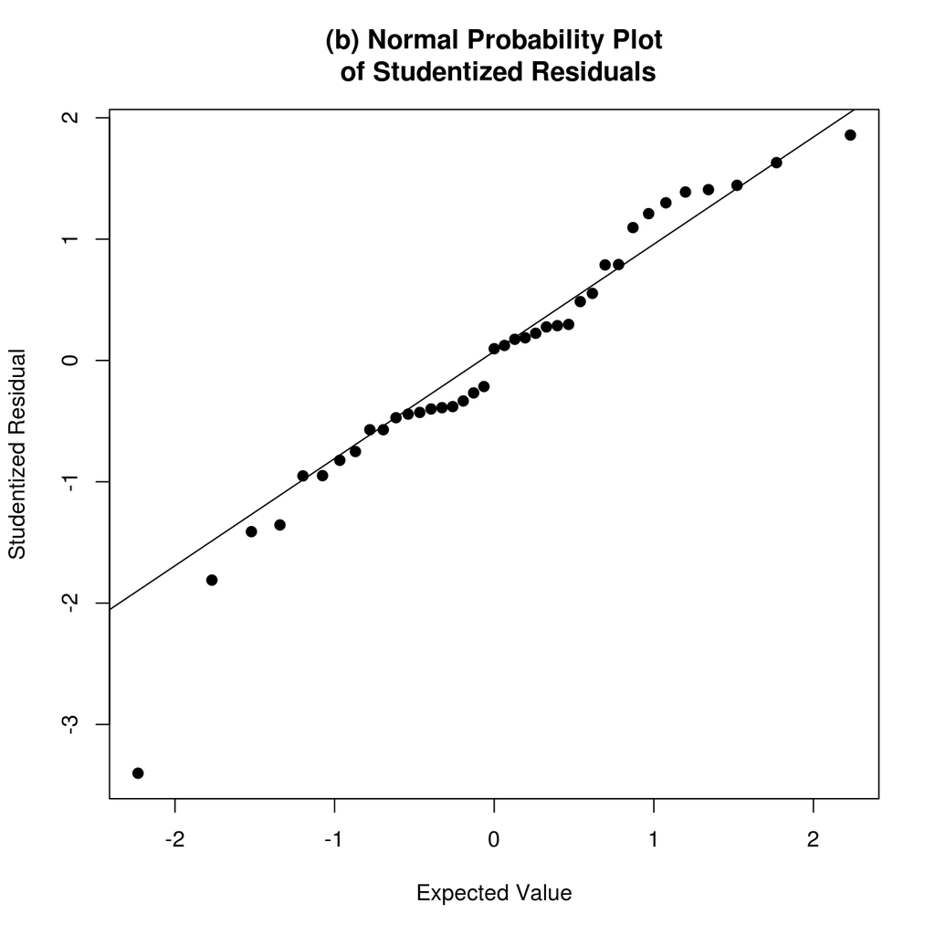

```r
qqnorm(rstudent(fit), pch = 19, xlab = "Expected Value", ylab = "Studentized Residual", main = "")
qqline(rstudent(fit))
title("(b) Normal Probability Plot\n of Studentized Residuals")
```